# Alpha-diversity longitudinal pairwise-comparison heatmap

This analysis evaluates longitudinal changes in three species-level alpha-diversity indices using six covariate-adjusted mixed-effects model specifications. Pairwise time-point contrasts are summarized in a 6-model by 3-index heatmap of raw P-value significance.

```r
required_packages <- c(
  "dplyr", "tidyr", "tibble", "ggplot2", "lme4", "lmerTest", "emmeans"
)

missing_packages <- required_packages[
  !vapply(required_packages, requireNamespace, logical(1), quietly = TRUE)
]
if (length(missing_packages) > 0L) {
  stop(
    "Install the following R packages before running this analysis: ",
    paste(missing_packages, collapse = ", ")
  )
}

set.seed(20260523)

input_file <- "000.input16S.Rds"
analysis_name <- "01.alpha_diversity_pairwise_heatmap"
output_root <- analysis_name
table_dir <- file.path(output_root, "tables")
model_dir <- file.path(output_root, "model_results")
figure_dir <- file.path(output_root, "figures")

dir.create(output_root, recursive = TRUE, showWarnings = FALSE)
dir.create(table_dir, recursive = TRUE, showWarnings = FALSE)
dir.create(model_dir, recursive = TRUE, showWarnings = FALSE)
dir.create(figure_dir, recursive = TRUE, showWarnings = FALSE)

# When the Rmd is knitted, any automatically generated supporting figures are
# also kept under the script-named output directory.
knitr::opts_chunk$set(
  fig.path = file.path(output_root, "knitr_figures", "")
)

group_order <- c(
  "001_BL", "002_D0", "003_D14", "004_M1", "005_M2",
  "006_M3", "007_M4", "008_M5", "009_M6"
)

model_order <- c(
  "main", "abx_recent", "abx_days_14", "broad_abx_14d",
  "clinical_age_sex", "clinical_age_sex_disease"
)

diversity_order <- c("Shannon", "Simpson", "Observed")
```

# 1 1. Prepare the analysis table

The released metadata fields correspond to the original analysis variables as follows:

- `Sample_Name` -> `sample_id`
- `Patient_ID` -> `pId`
- `pId_new` -> repeated-measures cycle identifier
- `timeIDcontiue` and `Timepoint` -> longitudinal analysis group
- `Age` -> `Age_years`
- `originSpecies_Shannon` -> `Shannon`
- `originSpecies_Simpson` -> `Simpson_raw`; the modeled index is `1 - Simpson_raw`
- `originSpecies_Sobs` -> `Observed`

The original analysis grouped the single D3 sample with D0 and the single D7 sample with D14. These two rules are retained explicitly below.

```r
if (!file.exists(input_file)) {
  stop("Input file not found: ", input_file)
}

input16S <- readRDS(input_file)
if (!is.list(input16S) || !all(c("dat_rela", "metainfo") %in% names(input16S))) {
  stop("000.input16S.Rds must contain dat_rela and metainfo.")
}

dat_rela <- input16S$dat_rela
metainfo <- input16S$metainfo

required_metadata <- c(
  "Timepoint", "Patient_ID", "CART_Cycle_ID", "Sample_Name", "pId_new",
  "Sex", "Age", "Disease", "timeIDcontiue", "project_id", "batch",
  "abx_recent", "abx_days_14", "broad_abx_14d",
  "originSpecies_Shannon", "originSpecies_Simpson", "originSpecies_Sobs"
)
missing_metadata <- setdiff(required_metadata, names(metainfo))
if (length(missing_metadata) > 0L) {
  stop("metainfo is missing required column(s): ", paste(missing_metadata, collapse = ", "))
}

if (!identical(colnames(dat_rela), as.character(metainfo$Sample_Name))) {
  stop("The abundance matrix columns are not aligned with metainfo$Sample_Name.")
}
if (anyDuplicated(metainfo$Sample_Name) || anyDuplicated(colnames(dat_rela))) {
  stop("Sample_Name must be unique in both dat_rela and metainfo.")
}

# Preserve the time grouping used to create the reference figure.
analysis_group <- as.character(metainfo$timeIDcontiue)
table(metainfo$Timepoint)
```

```
##
##  BL  D0 D14  D3  D7  M1  M2  M3  M4  M5  M6
##  28  19  26   1   1  32  22  24   4   3  12
```

```r
analysis_group[metainfo$Timepoint == "D3"] <- "002_D0"
analysis_group[metainfo$Timepoint == "D7"] <- "003_D14"

analysis_dat <- metainfo |>
  dplyr::transmute(
    sample_id = as.character(.data$Sample_Name),
    pId = as.character(.data$Patient_ID),
    pId_new = as.character(.data$pId_new),
    CART_Cycle_ID = as.character(.data$CART_Cycle_ID),
    Timepoint = as.character(.data$Timepoint),
    group_11 = factor(analysis_group, levels = group_order),
    batch = factor(.data$batch),
    Age_years = as.numeric(.data$Age),
    Sex = factor(.data$Sex),
    Disease = factor(.data$Disease),
    project_id = factor(.data$project_id),
    abx_recent = factor(.data$abx_recent, levels = c("No", "Yes")),
    abx_days_14 = as.numeric(.data$abx_days_14),
    broad_abx_14d = factor(.data$broad_abx_14d, levels = c("No", "Yes")),
    Shannon = as.numeric(.data$originSpecies_Shannon),
    Simpson_raw = as.numeric(.data$originSpecies_Simpson),
    Simpson = 1 - .data$Simpson_raw,
    Observed = as.numeric(.data$originSpecies_Sobs)
  ) |>
  dplyr::filter(!is.na(.data$group_11), !is.na(.data$batch)) |>
  droplevels()

if (anyNA(analysis_dat$abx_days_14)) {
  stop("abx_days_14 must be numeric and non-missing for all released samples.")
}

stopifnot(
  nrow(analysis_dat) == ncol(dat_rela),
  identical(analysis_dat$sample_id, colnames(dat_rela)),
  all(diversity_order %in% names(analysis_dat))
)

utils::write.csv(
  analysis_dat,
  file.path(table_dir, "01.alpha_diversity_analysis_data.csv"),
  row.names = FALSE,
  na = ""
)

sample_size_by_group <- analysis_dat |>
  dplyr::count(.data$group_11, name = "n_samples", .drop = FALSE)

utils::write.csv(
  sample_size_by_group,
  file.path(table_dir, "01.sample_size_by_group.csv"),
  row.names = FALSE
)
```

# 2 2. Fit mixed models and calculate raw pairwise P values

Each index is analyzed using a linear mixed model with a random intercept for `pId_new`. All models include longitudinal group and sequencing batch. The six rows of the final heatmap correspond to the base model and five prespecified sensitivity models.

```r
is_covariate_usable <- function(dat, variable) {
  if (!variable %in% names(dat)) return(FALSE)
  x <- dat[[variable]]

  if (is.factor(x) || is.character(x)) {
    return(nlevels(droplevels(factor(x))) >= 2L)
  }
  if (is.numeric(x)) {
    return(sum(!is.na(x)) >= 3L && stats::sd(x, na.rm = TRUE) > 0)
  }
  FALSE
}

fit_one_model <- function(dat, response, model_name, extra_covariates = character()) {
  selected_columns <- unique(c(
    "sample_id", "pId", "pId_new", "group_11", "batch",
    response, extra_covariates
  ))

  model_dat <- dat[, selected_columns, drop = FALSE]
  model_dat <- model_dat[
    !is.na(model_dat[[response]]) &
      !is.na(model_dat$group_11) &
      !is.na(model_dat$pId_new),
    , drop = FALSE
  ]
  model_dat <- droplevels(model_dat)

  fixed_terms <- "group_11"
  if (is_covariate_usable(model_dat, "batch")) {
    fixed_terms <- c(fixed_terms, "batch")
  }

  usable_extra <- extra_covariates[
    vapply(extra_covariates, function(x) is_covariate_usable(model_dat, x), logical(1))
  ]
  fixed_terms <- c(fixed_terms, usable_extra)

  complete_columns <- unique(c(response, "pId_new", fixed_terms))
  model_dat <- model_dat[stats::complete.cases(model_dat[, complete_columns, drop = FALSE]), , drop = FALSE]
  model_dat <- droplevels(model_dat)

  if (nrow(model_dat) < 6L || nlevels(model_dat$group_11) < 2L) {
    stop(response, " / ", model_name, ": insufficient complete observations.")
  }

  model_formula <- stats::as.formula(
    paste(response, "~", paste(fixed_terms, collapse = " + "), "+ (1 | pId_new)")
  )

  fit <- lmerTest::lmer(model_formula, data = model_dat, REML = FALSE)
  emm <- emmeans::emmeans(fit, ~ group_11)
  pairwise_raw <- as.data.frame(
    emmeans::contrast(emm, method = "pairwise", adjust = "none")
  )

  pairwise_raw |>
    dplyr::transmute(
      diversity = response,
      model = model_name,
      formula = paste(deparse(model_formula), collapse = " "),
      n_samples = nrow(model_dat),
      n_cycles = dplyr::n_distinct(model_dat$pId_new),
      singular_fit = lme4::isSingular(fit),
      contrast = as.character(.data$contrast),
      estimate = as.numeric(.data$estimate),
      SE = as.numeric(.data$SE),
      df = as.numeric(.data$df),
      t.ratio = as.numeric(.data$t.ratio),
      p.value.raw = as.numeric(.data$p.value)
    )
}
```

```r
model_covariates <- list(
  main = character(),
  abx_recent = "abx_recent",
  abx_days_14 = "abx_days_14",
  broad_abx_14d = "broad_abx_14d",
  clinical_age_sex = c("Age_years", "Sex"),
  clinical_age_sex_disease = c("Age_years", "Sex", "Disease")
)

pairwise_results <- list()
result_index <- 1L

for (diversity_name in diversity_order) {
  for (model_name in model_order) {
    pairwise_results[[result_index]] <- fit_one_model(
      dat = analysis_dat,
      response = diversity_name,
      model_name = model_name,
      extra_covariates = model_covariates[[model_name]]
    )
    result_index <- result_index + 1L
  }
}

pairwise_dat <- dplyr::bind_rows(pairwise_results)

utils::write.csv(
  pairwise_dat,
  file.path(model_dir, "01.emmeans_pairwise_group_raw_pvalues.csv"),
  row.names = FALSE,
  na = ""
)

model_summary <- pairwise_dat |>
  dplyr::distinct(
    .data$diversity, .data$model, .data$formula,
    .data$n_samples, .data$n_cycles, .data$singular_fit
  )

utils::write.csv(
  model_summary,
  file.path(model_dir, "01.alpha_model_summary.csv"),
  row.names = FALSE,
  na = ""
)

model_summary
```

```
##    diversity                    model
## 1    Shannon                     main
## 2    Shannon               abx_recent
## 3    Shannon              abx_days_14
## 4    Shannon            broad_abx_14d
## 5    Shannon         clinical_age_sex
## 6    Shannon clinical_age_sex_disease
## 7    Simpson                     main
## 8    Simpson               abx_recent
## 9    Simpson              abx_days_14
## 10   Simpson            broad_abx_14d
## 11   Simpson         clinical_age_sex
## 12   Simpson clinical_age_sex_disease
## 13  Observed                     main
## 14  Observed               abx_recent
```

[output cut: 42 more lines]

# 3 3. Draw the symmetric raw-P-value star heatmap

Pairwise comparisons are undirected, so each result is mirrored across the diagonal. Fill color represents `-log10(raw P)`. Asterisks use the nominal raw P-value thresholds in the reference figure.

```r
strip_group_prefix <- function(x) sub("^\\d+_", "", x)

format_p_star <- function(p) {
  ifelse(
    is.na(p), "",
    ifelse(p < 0.001, "***", ifelse(p < 0.01, "**", ifelse(p < 0.05, "*", "")))
  )
}

plot_dat_one_direction <- pairwise_dat |>
  tidyr::separate(
    .data$contrast,
    into = c("group_a", "group_b"),
    sep = " - ",
    remove = FALSE
  ) |>
  dplyr::transmute(
    diversity = .data$diversity,
    model = .data$model,
    group_a = .data$group_a,
    group_b = .data$group_b,
    p_raw = as.numeric(.data$p.value.raw)
  )

plot_dat_symmetric <- dplyr::bind_rows(
  plot_dat_one_direction |>
    dplyr::transmute(
      diversity, model,
      x_group = .data$group_a,
      y_group = .data$group_b,
      p_raw
    ),
  plot_dat_one_direction |>
    dplyr::transmute(
      diversity, model,
      x_group = .data$group_b,
      y_group = .data$group_a,
      p_raw
    )
)

diag_dat <- tidyr::expand_grid(
  diversity = diversity_order,
  model = model_order,
  x_group = group_order,
  y_group = group_order
) |>
  dplyr::filter(.data$x_group == .data$y_group) |>
  dplyr::mutate(p_raw = NA_real_)

heatmap_dat <- dplyr::bind_rows(plot_dat_symmetric, diag_dat) |>
  dplyr::mutate(
    model = factor(.data$model, levels = model_order),
    diversity = factor(.data$diversity, levels = diversity_order),
    x_group = factor(.data$x_group, levels = group_order),
    y_group = factor(.data$y_group, levels = rev(group_order)),
    p_star = format_p_star(.data$p_raw),
    neg_log10_p = ifelse(
      is.na(.data$p_raw), NA_real_, -log10(pmax(.data$p_raw, 1e-300))
    )
  )
```

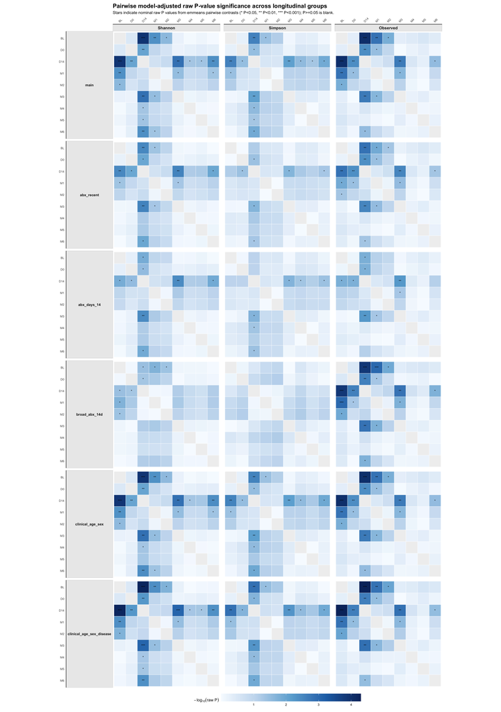

```r
p_heatmap_star <- ggplot2::ggplot(
  heatmap_dat,
  ggplot2::aes(x = .data$x_group, y = .data$y_group, fill = .data$neg_log10_p)
) +
  ggplot2::geom_tile(color = "white", linewidth = 0.22) +
  ggplot2::geom_text(
    ggplot2::aes(label = .data$p_star),
    size = 2.55,
    color = "black",
    lineheight = 0.85
  ) +
  ggplot2::facet_grid(model ~ diversity, switch = "y") +
  ggplot2::scale_x_discrete(labels = strip_group_prefix, position = "top") +
  ggplot2::scale_y_discrete(labels = strip_group_prefix) +
  ggplot2::scale_fill_gradientn(
    colours = c("#f7fbff", "#c6dbef", "#6baed6", "#2171b5", "#08306b"),
    na.value = "grey94",
    name = expression(-log[10]("raw P"))
  ) +
  ggplot2::labs(
    x = NULL,
    y = NULL,
    title = "Pairwise model-adjusted raw P-value significance across longitudinal groups",
    subtitle = paste0(
      "Stars indicate nominal raw P values from emmeans pairwise contrasts ",
      "(* P<0.05, ** P<0.01, *** P<0.001); P>=0.05 is blank."
    )
  ) +
  ggplot2::theme_classic(base_size = 9) +
  ggplot2::theme(
    plot.title = ggplot2::element_text(face = "bold", size = 13),
    plot.subtitle = ggplot2::element_text(size = 9),
    axis.text.x = ggplot2::element_text(angle = 45, hjust = 0, vjust = 0.5, size = 6.5),
    axis.text.y = ggplot2::element_text(size = 6.5),
    axis.ticks = ggplot2::element_blank(),
    strip.background = ggplot2::element_rect(fill = "grey92", color = "grey75", linewidth = 0.3),
    strip.text.x = ggplot2::element_text(face = "bold", size = 9),
    strip.text.y.left = ggplot2::element_text(face = "bold", angle = 0, size = 8),
    panel.spacing.x = grid::unit(0.55, "lines"),
    panel.spacing.y = grid::unit(0.35, "lines"),
    legend.position = "bottom",
    legend.key.width = grid::unit(2.2, "cm"),
    plot.margin = ggplot2::margin(8, 8, 8, 8)
  ) +
  ggplot2::coord_fixed()

pdf_file <- file.path(
  figure_dir,
  "supp_pairwise_raw_pvalue_star_heatmap_6x3.pdf"
)
ggplot2::ggsave(
  pdf_file,
  p_heatmap_star,
  width = 15.5,
  height = 22,
  device = "pdf"
)

p_heatmap_star
```